# Lesson 13 - Logarithmic Transformations (Part 1)

Robbie Beane

# Load and Explore the Data

We begin by reading in the data and looking at a summary of it.

```r
df <- read.table("ex01.txt", sep="\t", header=TRUE)
summary(df)
```

```
       x               y
 Min.   :2.124   Min.   :  8.333
 1st Qu.:3.795   1st Qu.: 31.661
 Median :5.436   Median : 78.320
 Mean   :5.358   Mean   :133.155
 3rd Qu.:6.944   3rd Qu.:199.158
 Max.   :7.979   Max.   :624.952
```

Create a scatterplot.

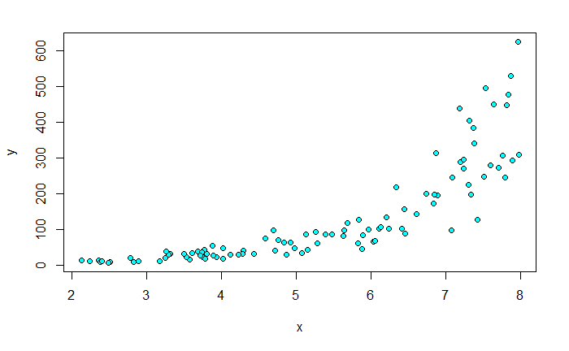

```r
plot(y ~ x, df, pch=21, col="black", bg="cyan")
```

# Linear Model

We will begin our analysis by considering a linear model of the form: $Y = \hat{\beta}_0 + \hat{\beta}_1 X + e$

```r
m1 <- lm(y ~ x, df)
summary(m1)
```

```
Call:
lm(formula = y ~ x, data = df)

Residuals:
    Min      1Q  Median      3Q     Max
-149.97  -50.98  -10.01   33.54  318.51

Coefficients:
            Estimate Std. Error t value Pr(>|t|)
(Intercept) -221.754     26.707  -8.303  5.7e-13 ***
x             66.240      4.746  13.958  < 2e-16 ***
---
Signif. codes:  0 ‘***’ 0.001 ‘**’ 0.01 ‘*’ 0.05 ‘.’ 0.1 ‘ ’ 1

Residual standard error: 81.69 on 98 degrees of freedom
Multiple R-squared:  0.6653,    Adjusted R-squared:  0.6619
F-statistic: 194.8 on 1 and 98 DF,  p-value: < 2.2e-16
```

Plot the fitted line.

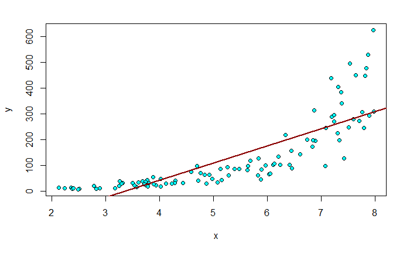

```r
plot(y ~ x, df, pch=21, col="black", bg="cyan")
abline(m1$coefficients, col="darkred", lwd=2)
```

We now create a residual plot.

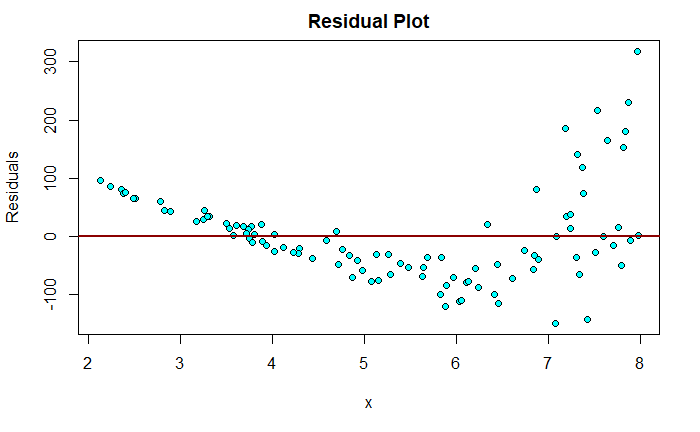

```r
plot(m1$residuals ~ df$x, pch=21, col="black", bg="cyan",
     xlab="x", ylab="Residuals", main="Residual Plot")
abline(h=0, col="darkred", lwd=2)
```

The residuals exhibit a trend, as well as heteroskedasticity (unequal variance).

We now assess the normality of the residuals with a histogram and a QQ-plot.

```r
res1 <- m1$residuals
par(mfrow=c(1,2))
hist(res1, col='orchid')
qqnorm(res1)
```

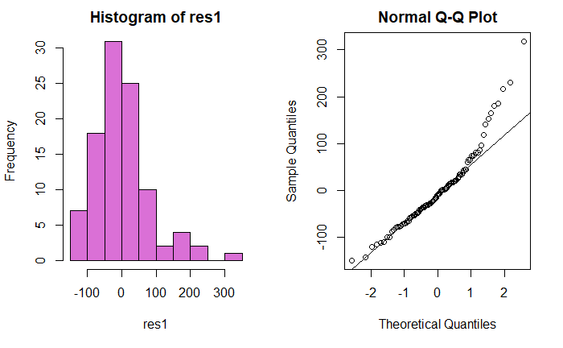

```r
qqline(res1)
par(mfrow=c(1,1))
```

These plots indicate that the residuals were drawn from a right-skewed distribution.

# Exponential Model

We will now consider a model of the form $Y = \hat{\beta}_0 + \hat{\beta}_1 e^X + \varepsilon$.

```r
m2 <- lm(y ~ exp(x), df)
summary(m2)
```

```
Call:
lm(formula = y ~ exp(x), data = df)

Residuals:
     Min       1Q   Median       3Q      Max
-173.688  -22.301   -5.473   21.888  202.380

Coefficients:
             Estimate Std. Error t value Pr(>|t|)
(Intercept) 32.869993   7.814467   4.206 5.75e-05 ***
exp(x)       0.153758   0.007461  20.607  < 2e-16 ***
---
Signif. codes:  0 ‘***’ 0.001 ‘**’ 0.01 ‘*’ 0.05 ‘.’ 0.1 ‘ ’ 1

Residual standard error: 61.14 on 98 degrees of freedom
Multiple R-squared:  0.8125,    Adjusted R-squared:  0.8106
F-statistic: 424.7 on 1 and 98 DF,  p-value: < 2.2e-16
```

We plot the fitted curve.

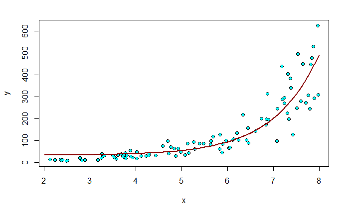

```r
plot(y ~ x, df, pch=21, col="black", bg="cyan")
ptn = seq(from=2,to=8, by=0.1)
lines(ptn, predict(m2, data.frame(x=ptn)), col="darkred", lwd=2)
```

We generate a residual plot.

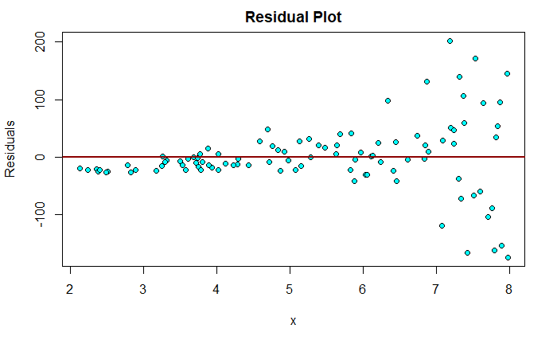

```r
plot(m2$residuals ~ df$x, pch=21, col="black", bg="cyan",
     xlab="x", ylab="Residuals", main="Residual Plot")
abline(h=0, col="darkred", lwd=2)
```

There is still a slight trend. The heteroskedasticity is also still present.

We will add prediction intervals to the scatterplot.

```r
plot(y ~ x, df, pch=21, col="black", bg="cyan")
p2 <- predict(m2, newdata=data.frame(x=ptn), interval="prediction", level=0.95)
lines(ptn, p2[,"fit"], col="darkred", lwd=2)
```

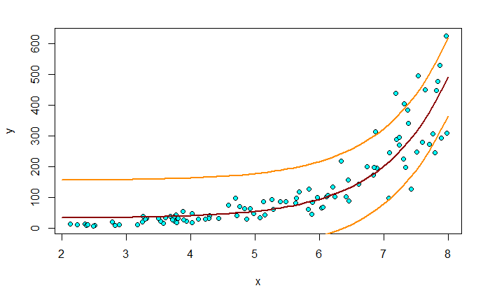

```r
lines(ptn, p2[,"lwr"], col="darkorange", lwd=2)
lines(ptn, p2[,"upr"], col="darkorange", lwd=2)
```

We now assess the normality of the residuals with a histogram and a QQ-plot.

```r
res2 <- m2$residuals
par(mfrow=c(1,2))
hist(res2, col='orchid')
qqnorm(res2)
```

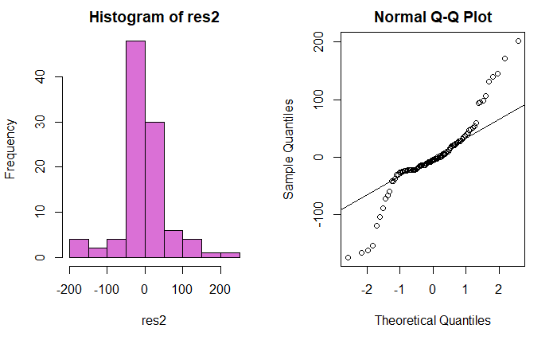

```r
qqline(res2)
par(mfrow=c(1,1))
```

These plots indicate that the residuals were drawn from a heavy-tailed distribution.

# Log-Level (or Log-Linear) Model

Let’s plot the natural log of y against x.

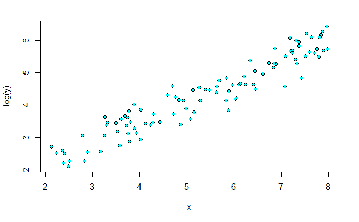

```r
plot(log(y) ~ x, df, pch=21, col="black", bg="cyan")
```

That looks like an excellent linear relationship. Perhaps we should consider a model of the form: $\ln(Y) = \hat{\beta}_0 + \hat{\beta}_1 X + \varepsilon$

```r
m3 <- lm(log(y) ~ x, df)
summary(m3)
```

```
Call:
lm(formula = log(y) ~ x, data = df)

Residuals:
     Min       1Q   Median       3Q      Max
-0.81094 -0.23060  0.03466  0.28640  0.67522

Coefficients:
            Estimate Std. Error t value Pr(>|t|)
(Intercept)  0.99771    0.11466   8.702 7.91e-14 ***
x            0.62018    0.02037  30.439  < 2e-16 ***
---
Signif. codes:  0 ‘***’ 0.001 ‘**’ 0.01 ‘*’ 0.05 ‘.’ 0.1 ‘ ’ 1

Residual standard error: 0.3507 on 98 degrees of freedom
Multiple R-squared:  0.9043,    Adjusted R-squared:  0.9034
F-statistic: 926.5 on 1 and 98 DF,  p-value: < 2.2e-16
```

Let’s consider the residual plot. Note that these are residuals of ln(Y), and not Y.

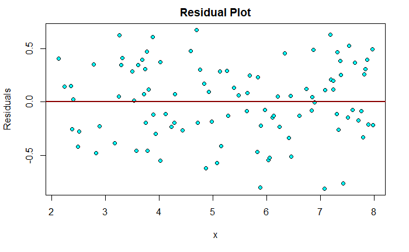

```r
plot(m3$residuals ~ df$x, pch=21, col="black", bg="cyan",
     xlab="x", ylab="Residuals", main="Residual Plot")
abline(h=0, col="darkred", lwd=2)
```

There is no apparent trend or heteroskedasticity in this residual plot.

We now assess the normality of the residuals with a histogram and a QQ-plot.

```r
res3 <- m3$residuals
par(mfrow=c(1,2))
hist(res3, col='orchid')
qqnorm(res3)
```

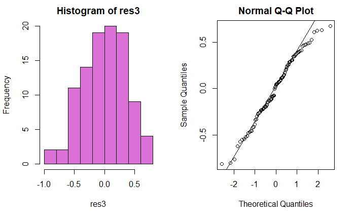

```r
qqline(res3)
par(mfrow=c(1,1))
```

These plots suggest that the residuals were likey drawn from a normal (or perhaps slightly left-skewed) distribution.

We will add the fitted curve and to the scatter plot of ln(y) against y.

```r
plot(log(y) ~ x, df, pch=21, col="black", bg="cyan")
p3 <- predict(m3, newdata=data.frame(x=ptn), interval="prediction", level=0.95)
lines(ptn, p3[,"fit"], col="darkred", lwd=2)
```

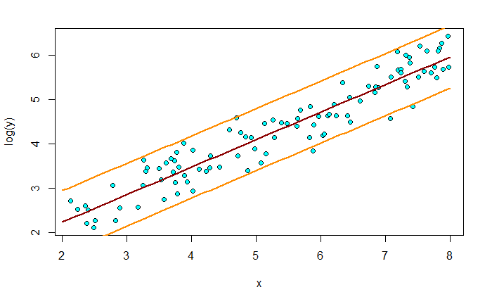

```r
lines(ptn, p3[,"lwr"], col="darkorange", lwd=2)
lines(ptn, p3[,"upr"], col="darkorange", lwd=2)
```

We can exponentiate the values of log(Y) to transform back to be in terms of Y.

```r
plot(y ~ x, df, pch=21, col="black", bg="cyan")
p3 <- predict(m3, newdata=data.frame(x=ptn), interval="prediction", level=0.95)
lines(ptn, exp(p3[,"fit"]), col="darkred", lwd=2)
```

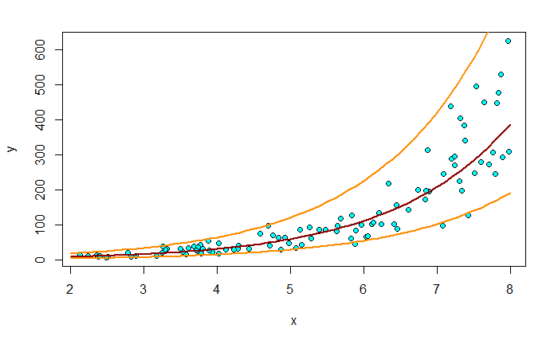

```r
lines(ptn, exp(p3[,"lwr"]), col="darkorange", lwd=2)
lines(ptn, exp(p3[,"upr"]), col="darkorange", lwd=2)
```

# Generating Predictions with the Transformed Model

When using this model to create predictions for Y, we need to first generate a prediction for ln(Y), and then exponentiate. Let’s construct a 95% prediction interval for Y when X = 6.5.

```r
ln_yhat = predict(m3, data.frame(x=c(6.5)), interval="prediction", level=0.95)
yhat = exp(ln_yhat)
yhat
```

```
       fit      lwr     upr
1 152.7606 75.78804 307.909
```

Note that we cannot directly compare r^2 values for linear and log-linear models. We can directly compare SSE values (assuming we transform everything back to Y), but we shouldn’t use SSE exclusively to determine which model to use.

```r
# Linear
sum((m1$residuals)^2)
```

```
[1] 653919.3
```

```r
sum((df$y - m1$fitted.values)^2)
```

```
[1] 653919.3
```

```r
# Exponential
sum((m2$residuals)^2)   # 366,355.6
```

```
[1] 366355.6
```

```r
# Log-Linear
sum((df$y - exp(m3$fitted.values))^2)
```

```
[1] 383890.1
```